# Analysis of field and evironmental data- April

Chelsey Wegener

4/8/2021

What’s new since last meeting (focused on research questions 1 and 2 (listed below) so these modifications only apply to those):

Things to consider:  
-fixed vs random sites. Doesn’t have to be apriori. Are the sites different? or are they spatial blocks?

Note for self (sing I keep forgetting): fixed factor use factor(x/factor of interest), for random factor just list column. For example, in lm(cover ~ factor(site) + month.yr, data =all), site is fized and month.yr is random

Questions for analysis:

ABUNDANCE (site only, no time)  
1. Is there a difference in Fucus abundance between sites?  
1.1 Is there a difference in Fucus percent cover amoung sites?  
1.2 Is there a difference in Fucus total density amoung sites?  
notes: include sampling date as random factor? Samples independent of each other? Time fixed or random? Find best fit (Gaussain, Poisson (density), normal). Percent cover as a proporation (i.e. 50% = 0.5)

-Site is the main factor. Sample month-year is a random factor but try both. Site is definitely a fixed factor.  
-when site and time are fixed, add an interaction term to assess model fit.

ABUNDANCE (site and time)  
2. Is there a difference in Fucus abundance between site and time? (site:time)  
2.1 Is there a difference in Fucus percent cover between site and time?  
2.2 Is there a difference in Fucus total density between site and time?  
notes: Find best fit (Gaussain, Poisson (density), normal). Seasonality time by quadrat. Percent cover as a proporation (i.e. 50% = 0.5)

-Seasonaly: time as fixed factor, site as a random factor (to account for the fact they spatially aggregated). –> are they all responding in the same way over time?

REPRODUCTIVE PHENOLOGY (with seasonality)  
3. Is reproduction affected by the season? 3.1 Is oogonia/receptacle affected by the season?  
3.2 Is oogonia/thalli affected by the season?  
3.3 Is conceptical/thalli affected by the season?  
3.4 Is percent reproductive tissue affected by the season?  
3.5 Is adult density affected by the season?  
3.6 Is juvenile density affected by the season?

REPRODUCTIVE PHENOLOGY (without seasonality)  
4. Is reproductive phenology affected by environmental conditions (salinity, pH, water temperature and air temperature)? *(not sure which metric of each variable I should be using? mean? daily min?)* For now I’m just using mean between survey dates which is a good starting point while I’m figuring out the code.  
4.1 Is oogoina/receptical affected by environmental conditions (salinity, pH, water temperature and air temperature)?  
4.2 Is oogonia/thalli affected by environmental conditions (salinity, pH, water temperature and air temperature)?  
4.3 Is conceptacle/thalli affected by environmental conditions (salinity, pH, water temperature and air temperature)?  
4.4 Is percent reproductive tissue affected by environmental conditions (salinity, pH, water temperature and air temperature)?  
4.5 Is juvenile density affected by environmental conditions (salinity, pH, water temperature and air temperature)?  
4.6 Is adult density affected by environmental conditions (salinity, pH, water temperature and air temperature)?  
notes: site and time as random factors. x ~ salintiy + ph + water temp + air temp + site(random) + time(random). In AIC ranking, do a model for every combination.

Additional inquires:  
-timing of oogonia/thalli -> juvenile abundance

Notes:  
-Time: month + year or season +year or season:year –> I don’t think I’m doing this correctly right now. I have a season year column and a month year column. I think it accomplishes the same thing but I should probably have these columns all separate and then add an iteraction term. So far season shows more of an effect than month so I’ll be using season-year for all “time” factors" in this markdown (at least for now).

**Set up**

```r
rm(list=ls())

library(tidyverse)
library(ggpubr)
library(scales)
library(chron)
library(plotly)
library(taRifx)
library(aweek)
library(easypackages)
library(renv)
library(here)
library(ggthemes)
library(gridExtra)
library(patchwork)
library(tidyquant)
library(recipes)
library(cranlogs)
library(knitr)
library(openair)

#new
library(AICcmodavg)
library(plm) #for random factors
library(lme4)
```

Read in data

```r
#read in data
all<-read.csv(
      "https://raw.githubusercontent.com/Cmwegener/thesis/master/data/environment_field/envi.field.all.csv",
    header = TRUE
  )
```

Make month year column. Was originally going to do just month but since I have some duplicate months I decided to do month-year. NOTE: since you need a day to convert to date format, I added the same date to all of them so that the only difference is the month-year which is what we’re really interested in anyway

```r
all$date<-as.Date(all$date, format = c("%Y-%m-%d"))

all$month.yr<-format(all$date, "%Y-%m") #can't convert month-year format as date so it's character, I'm going to assign them all the same date then so that it can be converted to a date

all$day<-"-01" #assigning place holder "day"
all$month.yr<-paste(all$month.yr,all$day, sep="")#merging with month.yr column
all$month.yr<-as.Date(all$month.yr, format=c("%Y-%m-%d")) #format as date

all<-subset(all, select = -c(day) ) #remove unneeded day column

#probably a much cleaner way to do this but this works
```

Season column. Split year into quarters. Added year since there’s some duplicate months? Since it’s a character I’ll need to list all the month.yr per season.  
2018-06 - 2018-08 summer.2018  
2018-09 - 2018-11 fall.2018  
2018-12 - 2019-02 winter.2018  
2019-03 - 2019-05 spring.2019  
2019-06 - 2019-08 summer.2019  
2019-09 - 2019-11 fall.2019 incomplete season, only have field data for 2019-09 –> Think I should probably remove this term and put “NA” since I only have field data for that month. Doesn’t seem right to compare it to the other seasons with more months and data.

```r
all$season[all$month.yr == "2018-06-01"] <- "summer.2018"
all$season[all$month.yr == "2018-07-01"] <- "summer.2018"
all$season[all$month.yr == "2018-08-01"] <- "summer.2018"

all$season[all$month.yr == "2018-09-01"] <- "fall.2018"
all$season[all$month.yr == "2018-10-01"] <- "fall.2018"
all$season[all$month.yr == "2018-11-01"] <- "fall.2018"

all$season[all$month.yr == "2018-12-01"] <- "winter.2018"
all$season[all$month.yr == "2019-01-01"] <- "winter.2018"
all$season[all$month.yr == "2019-02-01"] <- "winter.2018"

all$season[all$month.yr == "2019-03-01"] <- "spring.2019"
all$season[all$month.yr == "2019-04-01"] <- "spring.2019"
all$season[all$month.yr == "2019-05-01"] <- "spring.2019"

all$season[all$month.yr == "2019-06-01"] <- "summer.2019"
all$season[all$month.yr == "2019-07-01"] <- "summer.2019"
all$season[all$month.yr == "2019-08-01"] <- "summer.2019"

all$season[all$month.yr == "2019-09-01"] <- "fall.2019"
```

Converting percent cover as a proporation (i.e. 50% = 0.5) to make it easier to interpret

```r
all$cover<-all$cover/100
```

####ABUNDANCE (site only, no time)####  
1. Is there a difference in Fucus abundance between sites?  
1.1 Is there a difference in Fucus percent cover amoung sites?  
1.2 Is there a difference in Fucus total density amoung sites?  
notes: include sampling date as random factor? Samples independent of each other? Time fixed or random? Percent cover as a proporation (i.e. 50% = 0.5).  
Looking at site as fixed and random

Notes from most recent meeting:  
-Site is the main factor. Sample month-year is a random factor but try both. Site is definitely a fixed factor.  
-when site and time are fixed, add an interaction term to assess model fit.

####1.1 Is there a difference in Fucus percent cover amoung sites?####  
percent cover ~ Site as fixed factor + month-year as random

```r
lm1.1 <- lm(cover ~ factor(site) + month.yr, data =all)
lm1.1
```

```
##
## Call:
## lm(formula = cover ~ factor(site) + month.yr, data = all)
##
## Coefficients:
##        (Intercept)   factor(site)hs.fp  factor(site)nd.eos   factor(site)pc.cc
##          8.8468653          -0.1084375          -0.0878202          -0.0114250
##           month.yr
##         -0.0004728
```

```r
summary (lm1.1)
```

```
##
## Call:
## lm(formula = cover ~ factor(site) + month.yr, data = all)
##
## Residuals:
##      Min       1Q   Median       3Q      Max
## -0.23229 -0.07419  0.01286  0.08046  0.21931
##
## Coefficients:
##                      Estimate Std. Error t value Pr(>|t|)
## (Intercept)         8.8468653  1.8386227   4.812 1.17e-05 ***
## factor(site)hs.fp  -0.1084375  0.0402736  -2.693  0.00934 **
## factor(site)nd.eos -0.0878202  0.0409426  -2.145  0.03631 *
## factor(site)pc.cc  -0.0114250  0.0417085  -0.274  0.78515
## month.yr           -0.0004728  0.0001026  -4.606 2.41e-05 ***
## ---
## Signif. codes:  0 '***' 0.001 '**' 0.01 '*' 0.05 '.' 0.1 ' ' 1
##
## Residual standard error: 0.1139 on 56 degrees of freedom
## Multiple R-squared:  0.3593, Adjusted R-squared:  0.3136
## F-statistic: 7.853 on 4 and 56 DF,  p-value: 4.259e-05
```

```r
anova (lm1.1)
```

```
## Analysis of Variance Table
##
## Response: cover
##              Df  Sum Sq  Mean Sq F value   Pr(>F)
## factor(site)  3 0.13228 0.044095  3.3983  0.02389 *
## month.yr      1 0.27529 0.275291 21.2159 2.41e-05 ***
## Residuals    56 0.72664 0.012976
## ---
## Signif. codes:  0 '***' 0.001 '**' 0.01 '*' 0.05 '.' 0.1 ' ' 1
```

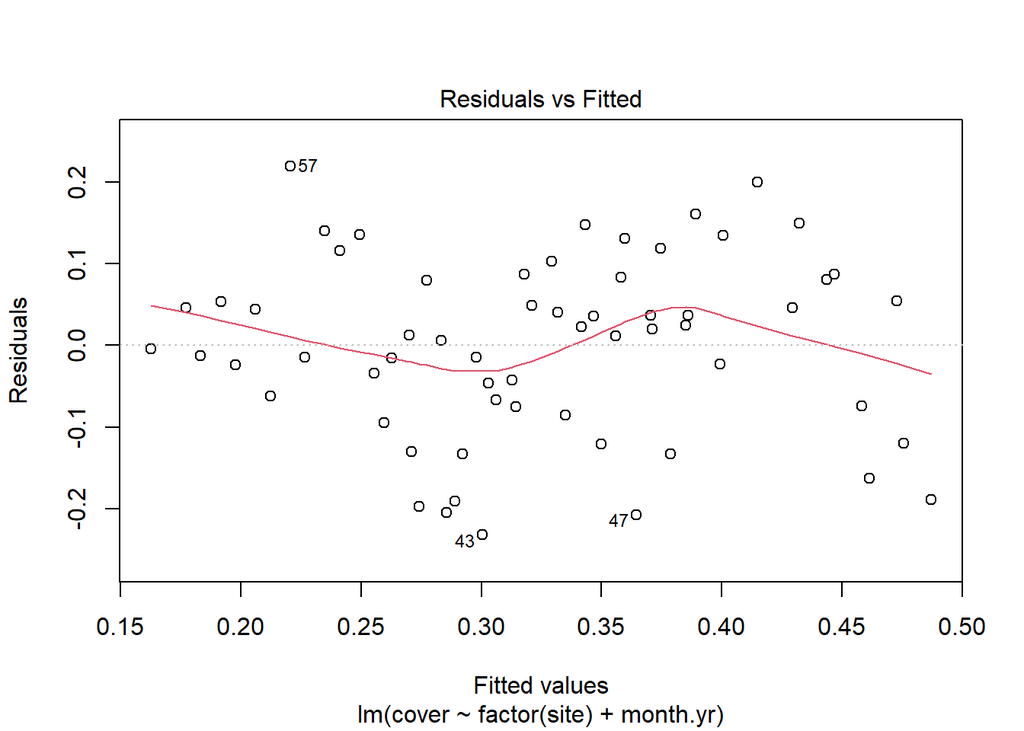

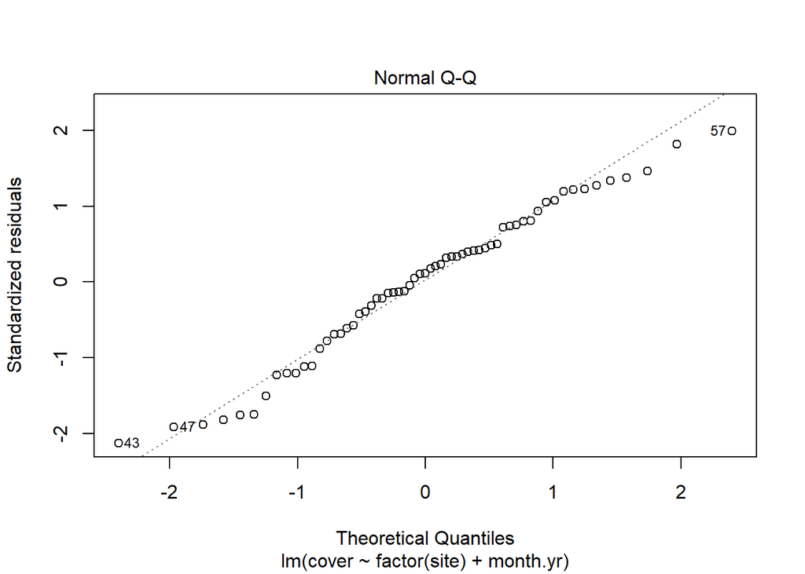

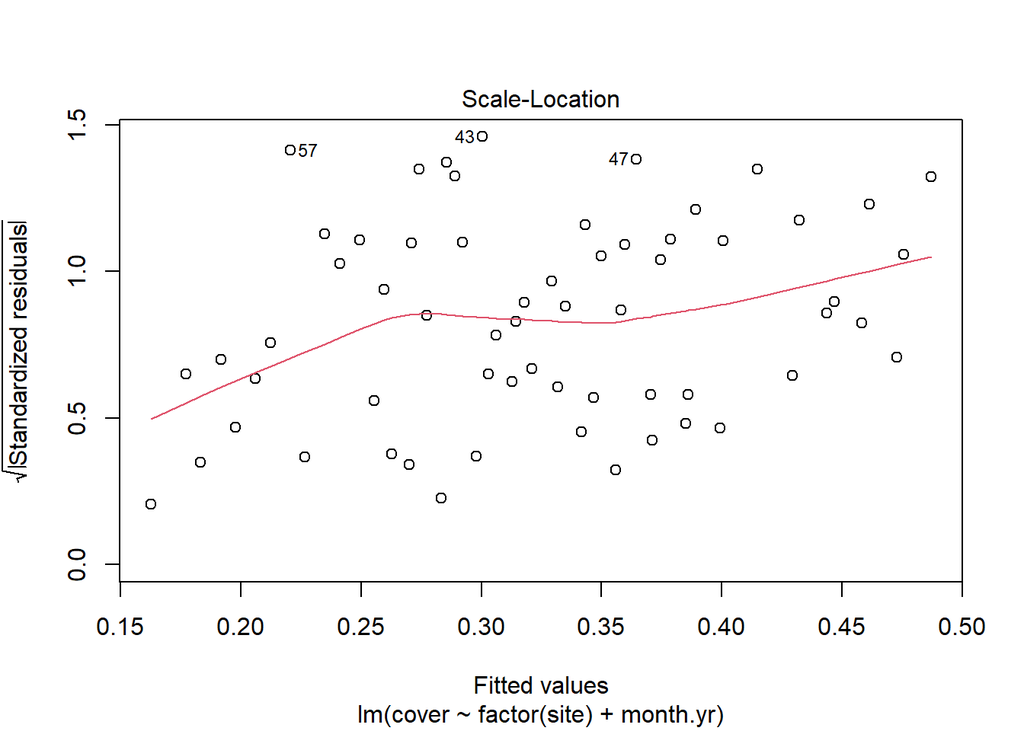

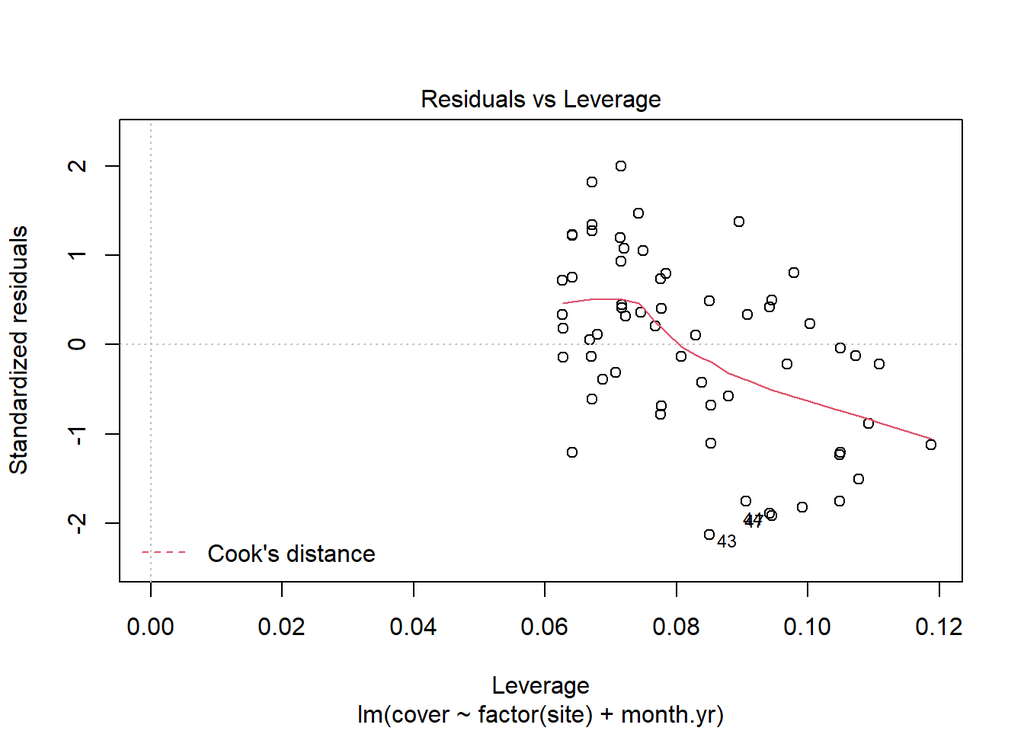

```r
plot (lm1.1)
```

both factors look significant, and model fit looks good enough

percent cover ~ Site as fixed factor + month-year as fixed factor + interaction term

```r
lm1.1 <- lm(cover ~ factor(site) + factor(month.yr) + site:month.yr, data =all)
lm1.1
```

```
##
## Call:
## lm(formula = cover ~ factor(site) + factor(month.yr) + site:month.yr,
##     data = all)
##
## Coefficients:
##                (Intercept)           factor(site)hs.fp
##                  5.040e-01                  -1.471e+01
##         factor(site)nd.eos           factor(site)pc.cc
##                 -3.604e+00                  -7.976e-02
## factor(month.yr)2018-07-01  factor(month.yr)2018-08-01
##                  2.176e-02                   5.427e-02
## factor(month.yr)2018-09-01  factor(month.yr)2018-10-01
##                  8.879e-02                   7.847e-02
## factor(month.yr)2018-11-01  factor(month.yr)2018-12-01
##                  8.808e-02                   1.382e-02
## factor(month.yr)2019-01-01  factor(month.yr)2019-02-01
##                  1.658e-02                  -2.565e-02
## factor(month.yr)2019-03-01  factor(month.yr)2019-04-01
##                 -1.439e-02                  -3.013e-02
## factor(month.yr)2019-05-01  factor(month.yr)2019-06-01
##                  6.132e-03                  -1.706e-01
## factor(month.yr)2019-07-01  factor(month.yr)2019-08-01
##                 -2.773e-01                  -2.866e-01
## factor(month.yr)2019-09-01          siteby.rb:month.yr
##                 -2.746e-01                  -4.491e-06
##         sitehs.fp:month.yr         sitend.eos:month.yr
##                  8.108e-04                   1.921e-04
##         sitepc.cc:month.yr
##                         NA
```

```r
summary (lm1.1)
```

```
##
## Call:
## lm(formula = cover ~ factor(site) + factor(month.yr) + site:month.yr,
##     data = all)
##
## Residuals:
##       Min        1Q    Median        3Q       Max
## -0.146970 -0.048865 -0.005254  0.054135  0.116080
##
## Coefficients: (1 not defined because of singularities)
##                              Estimate Std. Error t value Pr(>|t|)
## (Intercept)                 5.040e-01  3.774e+00   0.134 0.894450
## factor(site)hs.fp          -1.471e+01  3.714e+00  -3.961 0.000308 ***
## factor(site)nd.eos         -3.604e+00  3.742e+00  -0.963 0.341508
## factor(site)pc.cc          -7.976e-02  3.800e+00  -0.021 0.983360
## factor(month.yr)2018-07-01  2.176e-02  5.826e-02   0.374 0.710771
## factor(month.yr)2018-08-01  5.427e-02  5.867e-02   0.925 0.360644
## factor(month.yr)2018-09-01  8.879e-02  5.936e-02   1.496 0.142799
## factor(month.yr)2018-10-01  7.847e-02  6.402e-02   1.226 0.227650
## factor(month.yr)2018-11-01  8.808e-02  7.395e-02   1.191 0.240827
## factor(month.yr)2018-12-01  1.382e-02  6.288e-02   0.220 0.827159
## factor(month.yr)2019-01-01  1.658e-02  6.454e-02   0.257 0.798557
## factor(month.yr)2019-02-01 -2.565e-02  6.641e-02  -0.386 0.701383
## factor(month.yr)2019-03-01 -1.439e-02  6.826e-02  -0.211 0.834111
## factor(month.yr)2019-04-01 -3.013e-02  7.047e-02  -0.428 0.671352
## factor(month.yr)2019-05-01  6.132e-03  7.277e-02   0.084 0.933272
## factor(month.yr)2019-06-01 -1.706e-01  7.529e-02  -2.266 0.029072 *
## factor(month.yr)2019-07-01 -2.773e-01  7.784e-02  -3.563 0.000987 ***
## factor(month.yr)2019-08-01 -2.866e-01  8.060e-02  -3.555 0.001008 **
## factor(month.yr)2019-09-01 -2.746e-01  8.347e-02  -3.289 0.002134 **
## siteby.rb:month.yr         -4.491e-06  2.120e-04  -0.021 0.983208
## sitehs.fp:month.yr          8.108e-04  2.120e-04   3.824 0.000462 ***
## sitend.eos:month.yr         1.921e-04  2.125e-04   0.904 0.371560
## sitepc.cc:month.yr                 NA         NA      NA       NA
## ---
## Signif. codes:  0 '***' 0.001 '**' 0.01 '*' 0.05 '.' 0.1 ' ' 1
##
## Residual standard error: 0.0822 on 39 degrees of freedom
## Multiple R-squared:  0.7677, Adjusted R-squared:  0.6425
## F-statistic: 6.136 on 21 and 39 DF,  p-value: 5.918e-07
```

```r
anova (lm1.1)
```

```
## Analysis of Variance Table
##
## Response: cover
##                  Df  Sum Sq  Mean Sq F value    Pr(>F)
## factor(site)      3 0.13228 0.044095  6.5255 0.0011031 **
## factor(month.yr) 15 0.60030 0.040020  5.9225 3.821e-06 ***
## site:month.yr     3 0.13810 0.046033  6.8124 0.0008404 ***
## Residuals        39 0.26353 0.006757
## ---
## Signif. codes:  0 '***' 0.001 '**' 0.01 '*' 0.05 '.' 0.1 ' ' 1
```

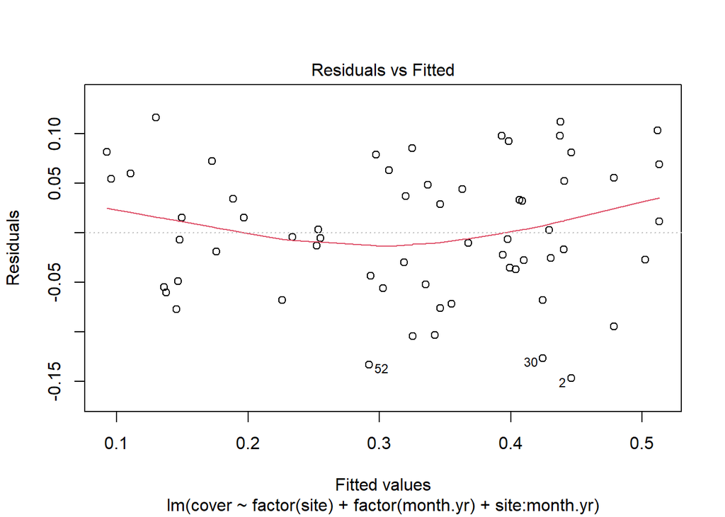

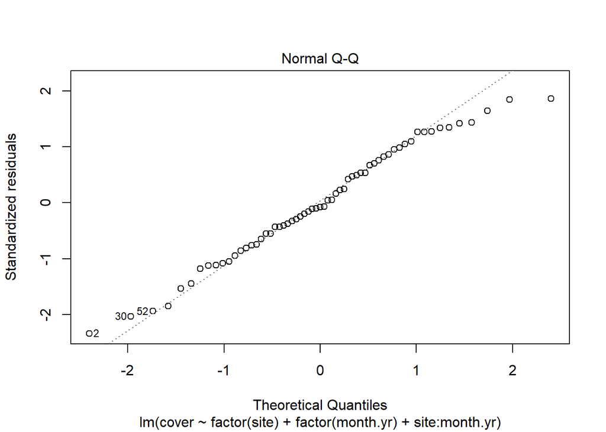

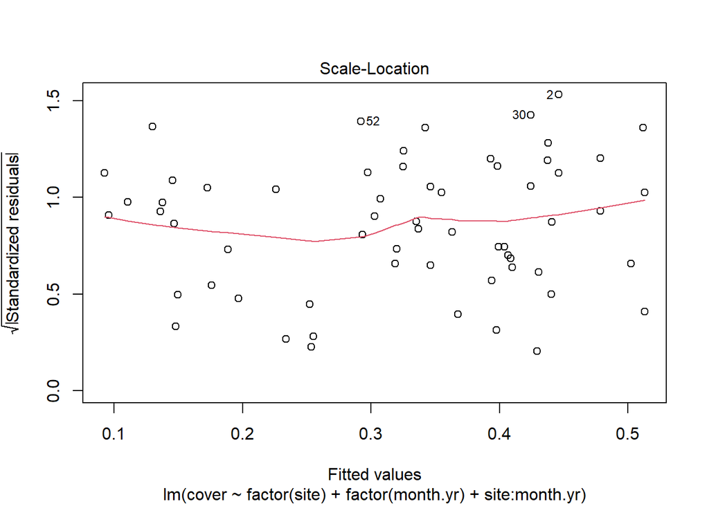

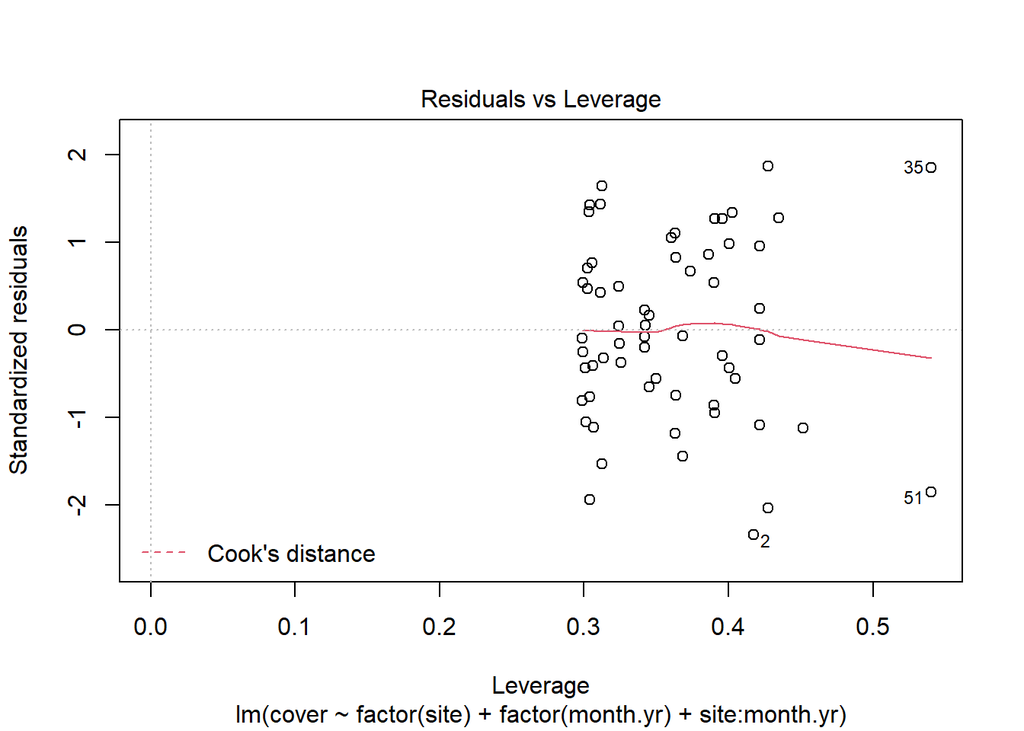

```r
plot (lm1.1)
```

Both significant, not sure about Residuals vs Leverage plot

####1.2 Is there a difference in Fucus total density amoung sites?###  
density ~ site as fixed factor + month-year as random

```r
lm1.2 <- lm(no.fuc.q ~ factor(site) + month.yr, data =all)
lm1.2
```

```
##
## Call:
## lm(formula = no.fuc.q ~ factor(site) + month.yr, data = all)
##
## Coefficients:
##        (Intercept)   factor(site)hs.fp  factor(site)nd.eos   factor(site)pc.cc
##          2245.5084            -30.3625             -9.0141             -2.9728
##           month.yr
##            -0.1227
```

```r
summary (lm1.2)
```

```
##
## Call:
## lm(formula = no.fuc.q ~ factor(site) + month.yr, data = all)
##
## Residuals:
##     Min      1Q  Median      3Q     Max
## -43.583 -19.693  -4.829  13.943  97.399
##
## Coefficients:
##                     Estimate Std. Error t value Pr(>|t|)
## (Intercept)        2245.5084   454.9479   4.936 7.54e-06 ***
## factor(site)hs.fp   -30.3625     9.9653  -3.047  0.00352 **
## factor(site)nd.eos   -9.0141    10.1308  -0.890  0.37740
## factor(site)pc.cc    -2.9728    10.3203  -0.288  0.77437
## month.yr             -0.1227     0.0254  -4.830 1.10e-05 ***
## ---
## Signif. codes:  0 '***' 0.001 '**' 0.01 '*' 0.05 '.' 0.1 ' ' 1
##
## Residual standard error: 28.19 on 56 degrees of freedom
## Multiple R-squared:  0.3782, Adjusted R-squared:  0.3338
## F-statistic: 8.517 on 4 and 56 DF,  p-value: 1.93e-05
```

```r
anova (lm1.2)
```

```
## Analysis of Variance Table
##
## Response: no.fuc.q
##              Df Sum Sq Mean Sq F value    Pr(>F)
## factor(site)  3   8534  2844.5  3.5805   0.01933 *
## month.yr      1  18531 18530.9 23.3253 1.099e-05 ***
## Residuals    56  44490   794.5
## ---
## Signif. codes:  0 '***' 0.001 '**' 0.01 '*' 0.05 '.' 0.1 ' ' 1
```

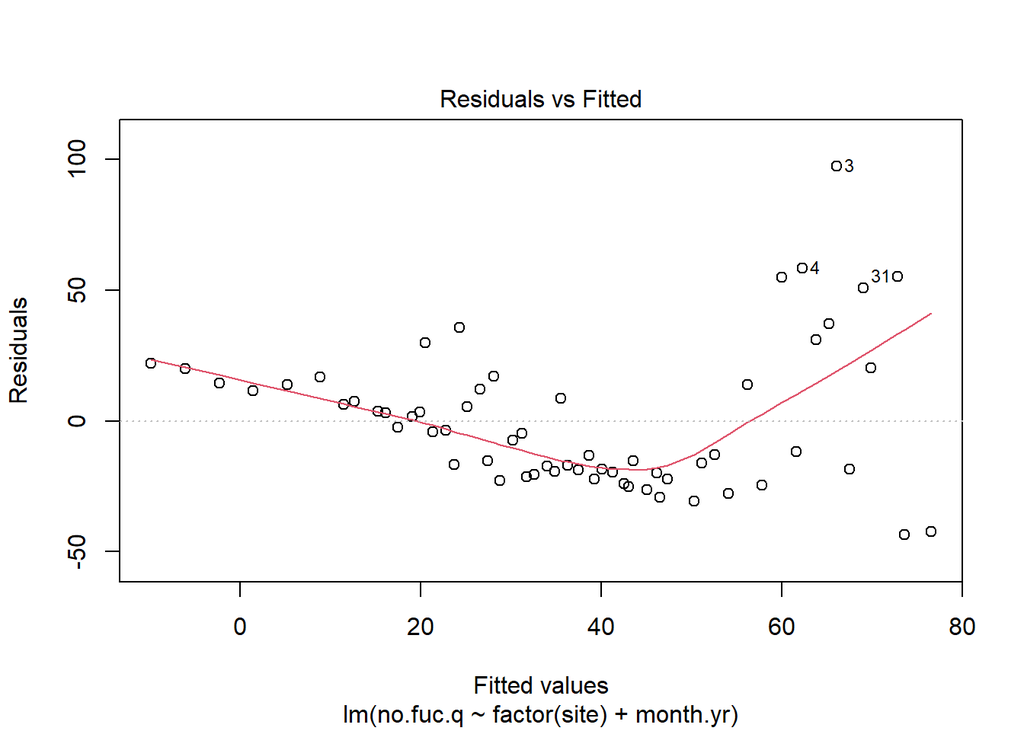

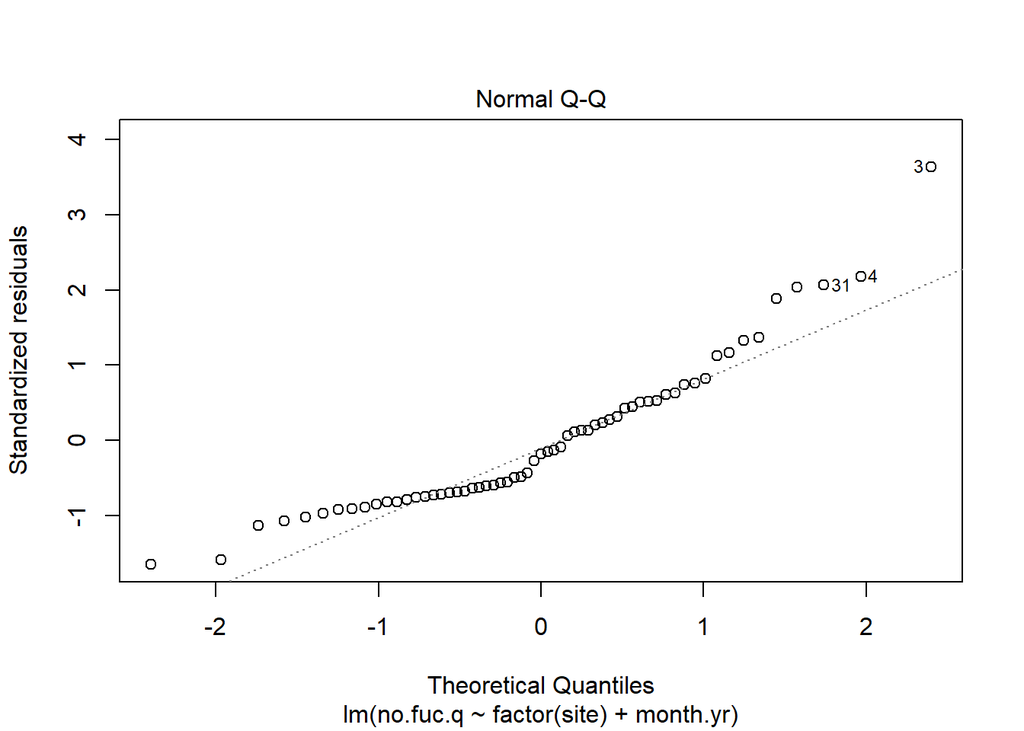

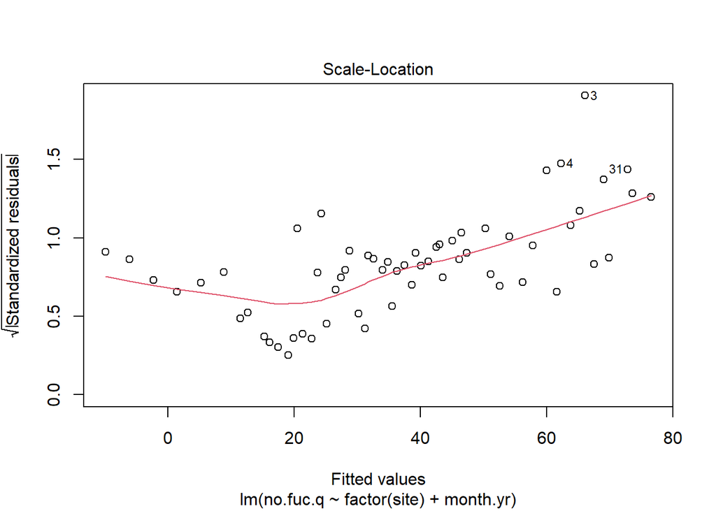

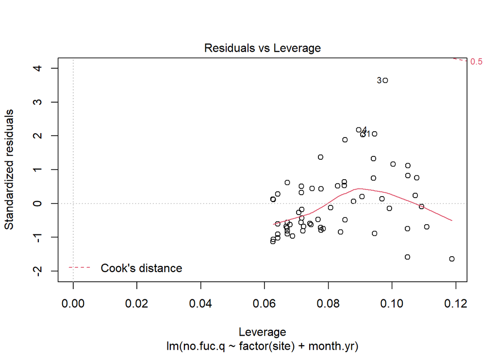

```r
plot (lm1.2)
```

density ~ site as fixed factor + month.yr as fixed factor + interaction term

```r
lm1.2 <- lm(no.fuc.q ~ factor(site) + factor(month.yr) + site:month.yr, data =all)
lm1.2
```

```
##
## Call:
## lm(formula = no.fuc.q ~ factor(site) + factor(month.yr) + site:month.yr,
##     data = all)
##
## Coefficients:
##                (Intercept)           factor(site)hs.fp
##                 -1.420e+03                  -1.807e+03
##         factor(site)nd.eos           factor(site)pc.cc
##                  4.902e+02                   1.481e+03
## factor(month.yr)2018-07-01  factor(month.yr)2018-08-01
##                  4.568e+01                   6.612e+01
## factor(month.yr)2018-09-01  factor(month.yr)2018-10-01
##                  3.494e+01                  -7.665e-01
## factor(month.yr)2018-11-01  factor(month.yr)2018-12-01
##                 -1.631e+01                  -2.769e+01
## factor(month.yr)2019-01-01  factor(month.yr)2019-02-01
##                 -2.959e+01                  -3.357e+01
## factor(month.yr)2019-03-01  factor(month.yr)2019-04-01
##                 -3.756e+01                  -3.801e+01
## factor(month.yr)2019-05-01  factor(month.yr)2019-06-01
##                 -3.309e+01                  -5.189e+01
## factor(month.yr)2019-07-01  factor(month.yr)2019-08-01
##                 -3.937e+01                  -4.147e+01
## factor(month.yr)2019-09-01          siteby.rb:month.yr
##                 -4.763e+01                   8.288e-02
##         sitehs.fp:month.yr         sitend.eos:month.yr
##                  1.821e-01                   5.495e-02
##         sitepc.cc:month.yr
##                         NA
```

```r
summary (lm1.2)
```

```
##
## Call:
## lm(formula = no.fuc.q ~ factor(site) + factor(month.yr) + site:month.yr,
##     data = all)
##
## Residuals:
##     Min      1Q  Median      3Q     Max
## -43.963 -10.954  -1.371   9.329  36.748
##
## Coefficients: (1 not defined because of singularities)
##                              Estimate Std. Error t value Pr(>|t|)
## (Intercept)                -1.420e+03  8.785e+02  -1.617 0.113995
## factor(site)hs.fp          -1.807e+03  8.646e+02  -2.090 0.043157 *
## factor(site)nd.eos          4.902e+02  8.712e+02   0.563 0.576835
## factor(site)pc.cc           1.481e+03  8.845e+02   1.674 0.102080
## factor(month.yr)2018-07-01  4.568e+01  1.356e+01   3.368 0.001714 **
## factor(month.yr)2018-08-01  6.612e+01  1.366e+01   4.841 2.07e-05 ***
## factor(month.yr)2018-09-01  3.494e+01  1.382e+01   2.529 0.015612 *
## factor(month.yr)2018-10-01 -7.665e-01  1.490e+01  -0.051 0.959239
## factor(month.yr)2018-11-01 -1.631e+01  1.722e+01  -0.948 0.349130
## factor(month.yr)2018-12-01 -2.769e+01  1.464e+01  -1.891 0.066013 .
## factor(month.yr)2019-01-01 -2.959e+01  1.502e+01  -1.970 0.056025 .
## factor(month.yr)2019-02-01 -3.357e+01  1.546e+01  -2.172 0.036033 *
## factor(month.yr)2019-03-01 -3.756e+01  1.589e+01  -2.364 0.023168 *
## factor(month.yr)2019-04-01 -3.801e+01  1.641e+01  -2.317 0.025836 *
## factor(month.yr)2019-05-01 -3.309e+01  1.694e+01  -1.953 0.057989 .
## factor(month.yr)2019-06-01 -5.189e+01  1.753e+01  -2.961 0.005197 **
## factor(month.yr)2019-07-01 -3.937e+01  1.812e+01  -2.172 0.035962 *
## factor(month.yr)2019-08-01 -4.147e+01  1.876e+01  -2.210 0.033026 *
## factor(month.yr)2019-09-01 -4.763e+01  1.943e+01  -2.451 0.018830 *
## siteby.rb:month.yr          8.288e-02  4.936e-02   1.679 0.101108
## sitehs.fp:month.yr          1.821e-01  4.936e-02   3.689 0.000685 ***
## sitend.eos:month.yr         5.495e-02  4.947e-02   1.111 0.273467
## sitepc.cc:month.yr                 NA         NA      NA       NA
## ---
## Signif. codes:  0 '***' 0.001 '**' 0.01 '*' 0.05 '.' 0.1 ' ' 1
##
## Residual standard error: 19.14 on 39 degrees of freedom
## Multiple R-squared:  0.8004, Adjusted R-squared:  0.693
## F-statistic: 7.448 on 21 and 39 DF,  p-value: 4.419e-08
```

```r
anova (lm1.2)
```

```
## Analysis of Variance Table
##
## Response: no.fuc.q
##                  Df Sum Sq Mean Sq F value    Pr(>F)
## factor(site)      3   8534 2844.51  7.7683 0.0003479 ***
## factor(month.yr) 15  43443 2896.17  7.9094 1.038e-07 ***
## site:month.yr     3   5297 1765.78  4.8223 0.0059722 **
## Residuals        39  14281  366.17
## ---
## Signif. codes:  0 '***' 0.001 '**' 0.01 '*' 0.05 '.' 0.1 ' ' 1
```

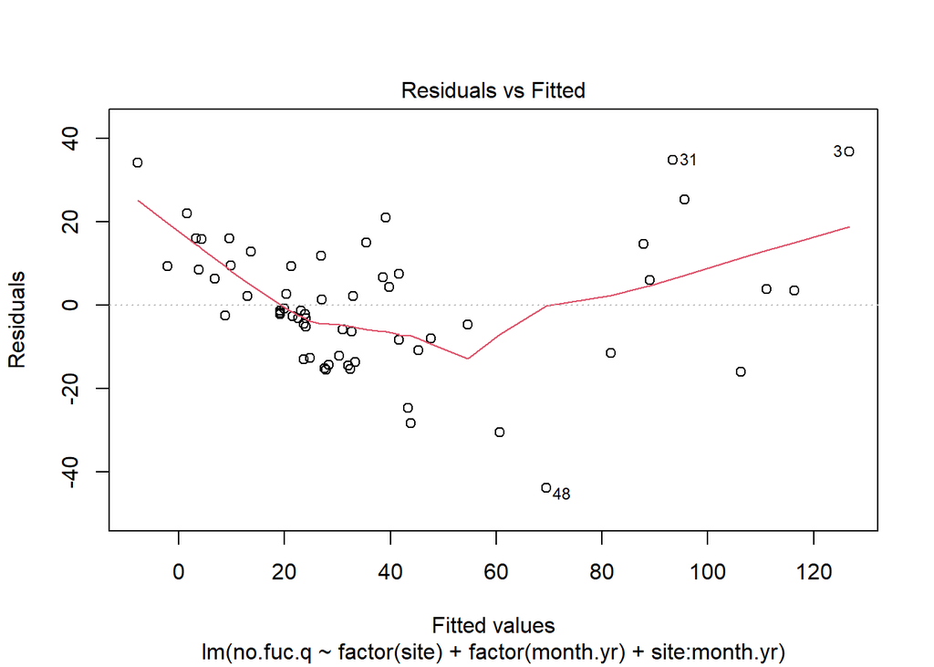

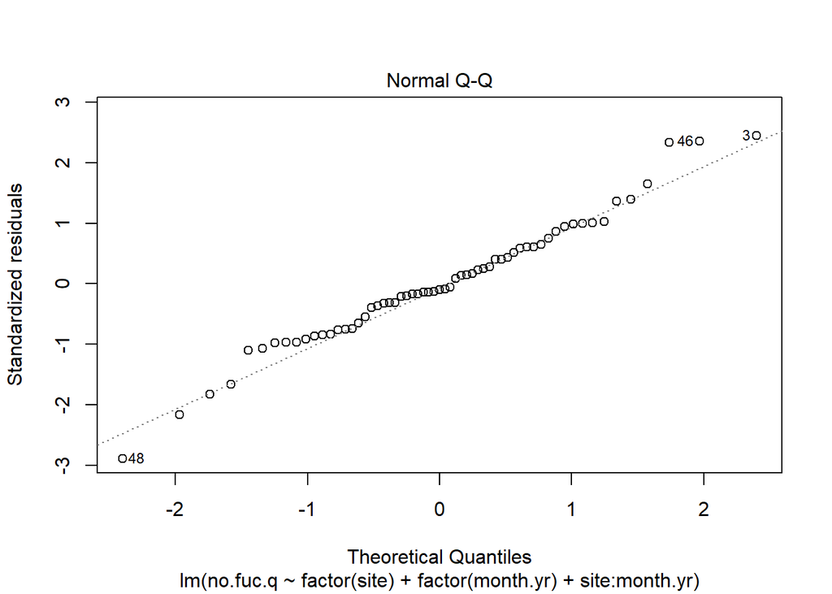

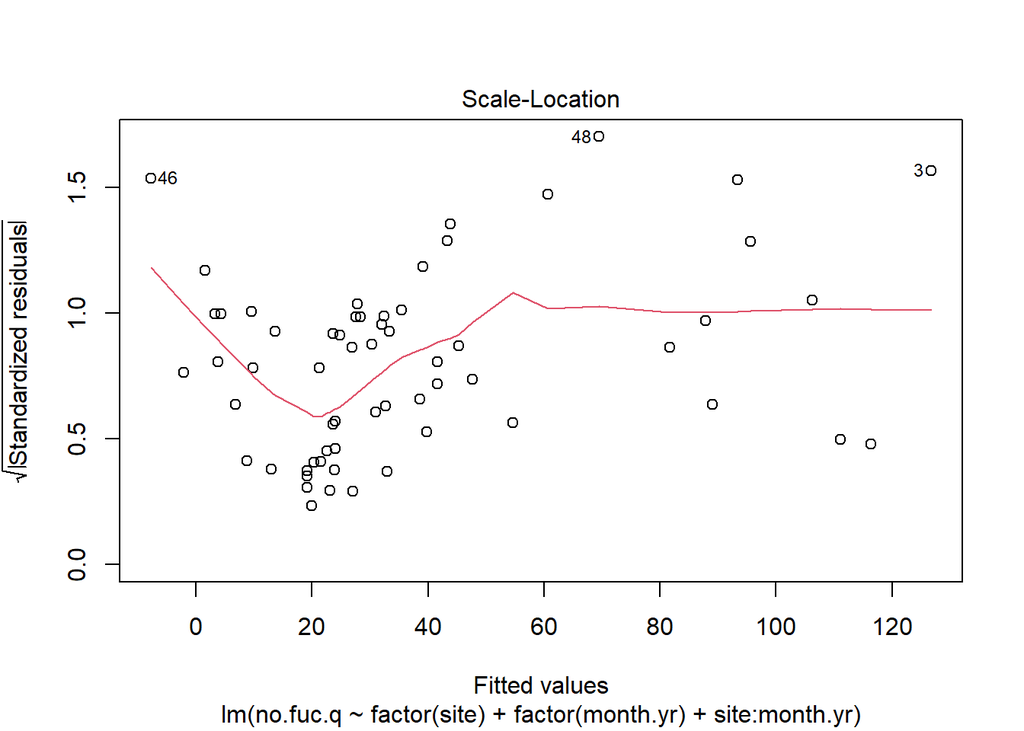

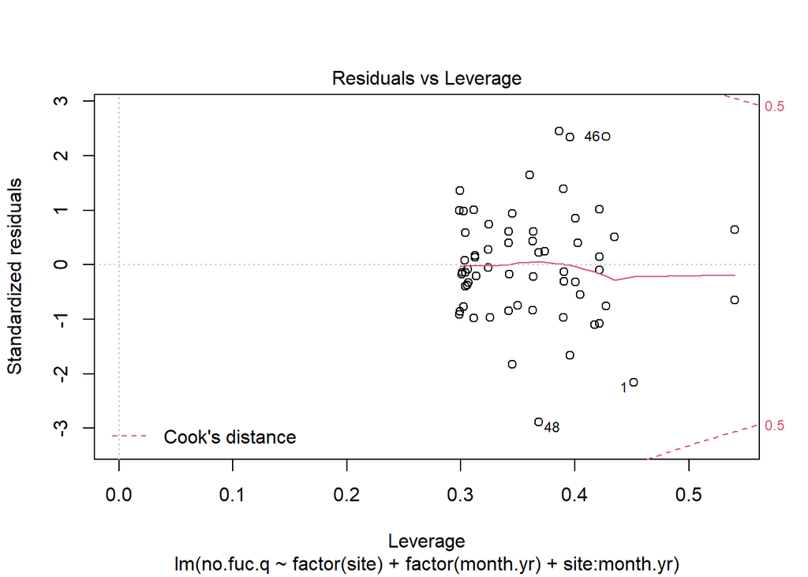

```r
plot (lm1.2)
```

####ABUNDANCE (site and time)####  
2. Is there a difference in Fucus abundance between site and time? (site:time)  
2.1 Is there a difference in Fucus percent cover between site and time?  
2.2 Is there a difference in Fucus total density between site and time?  
notes:Find best fit (Gaussain, Poisson (density), normal). Seasonality time by quadrat. Percent cover as a proporation (i.e. 50% = 0.5)

From last meeting: Seasonaly: time as fixed factor, site as a random factor (to account for the fact they spatially aggregated). –> are they all responding in the same way over time?

####2.1 Is there a difference in Fucus percent cover between site and time?####  
cover ~ site as random factor + season as fixed factor

```r
lm2.1 <- lm(cover ~ site + factor(season), data =all)
lm2.1
```

```
##
## Call:
## lm(formula = cover ~ site + factor(season), data = all)
##
## Coefficients:
##               (Intercept)                  sitehs.fp
##                  0.475838                  -0.108437
##                sitend.eos                  sitepc.cc
##                 -0.083744                  -0.003737
##   factor(season)fall.2019  factor(season)spring.2019
##                 -0.268358                  -0.044858
## factor(season)summer.2018  factor(season)summer.2019
##                 -0.074941                  -0.254024
## factor(season)winter.2018
##                 -0.052858
```

```r
summary (lm2.1)
```

```
##
## Call:
## lm(formula = cover ~ site + factor(season), data = all)
##
## Residuals:
##      Min       1Q   Median       3Q      Max
## -0.15554 -0.06346  0.00102  0.06246  0.13916
##
## Coefficients:
##                            Estimate Std. Error t value Pr(>|t|)
## (Intercept)                0.475838   0.035849  13.274  < 2e-16 ***
## sitehs.fp                 -0.108437   0.032715  -3.315  0.00168 **
## sitend.eos                -0.083744   0.033306  -2.514  0.01506 *
## sitepc.cc                 -0.003737   0.034089  -0.110  0.91312
## factor(season)fall.2019   -0.268358   0.055785  -4.811 1.33e-05 ***
## factor(season)spring.2019 -0.044858   0.041048  -1.093  0.27951
## factor(season)summer.2018 -0.074941   0.041048  -1.826  0.07364 .
## factor(season)summer.2019 -0.254024   0.041048  -6.188 9.69e-08 ***
## factor(season)winter.2018 -0.052858   0.041048  -1.288  0.20355
## ---
## Signif. codes:  0 '***' 0.001 '**' 0.01 '*' 0.05 '.' 0.1 ' ' 1
##
## Residual standard error: 0.09253 on 52 degrees of freedom
## Multiple R-squared:  0.6074, Adjusted R-squared:  0.5471
## F-statistic: 10.06 on 8 and 52 DF,  p-value: 2.433e-08
```

```r
anova (lm2.1)
```

```
## Analysis of Variance Table
##
## Response: cover
##                Df  Sum Sq  Mean Sq F value    Pr(>F)
## site            3 0.13228 0.044095  5.1499  0.003417 **
## factor(season)  5 0.55669 0.111338 13.0032 3.216e-08 ***
## Residuals      52 0.44524 0.008562
## ---
## Signif. codes:  0 '***' 0.001 '**' 0.01 '*' 0.05 '.' 0.1 ' ' 1
```

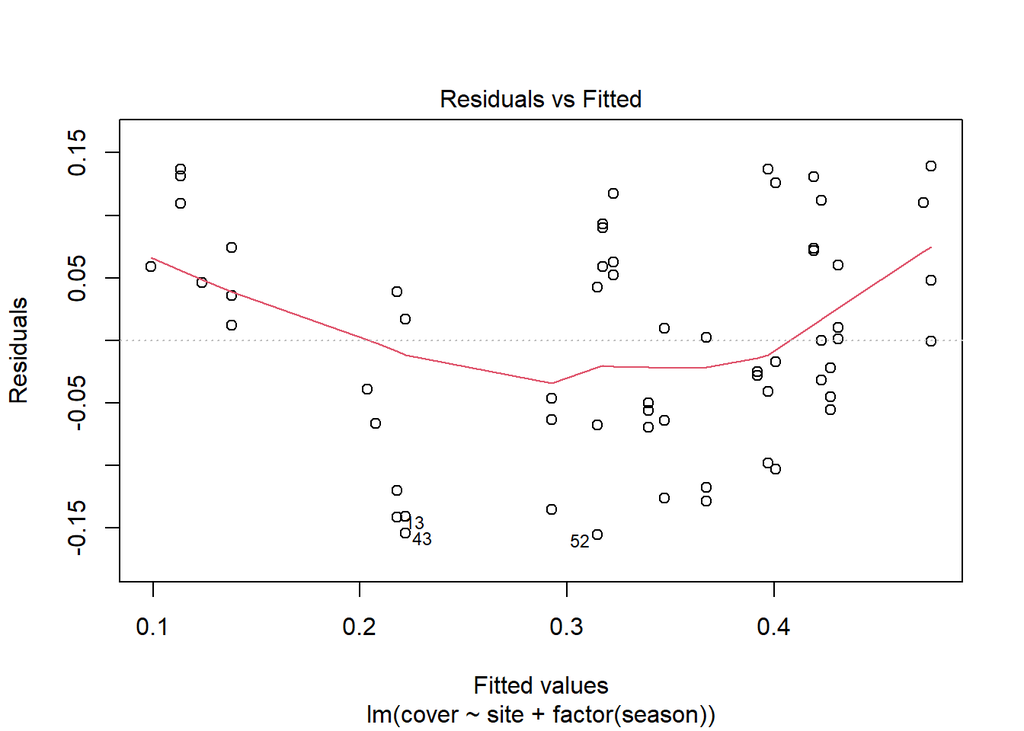

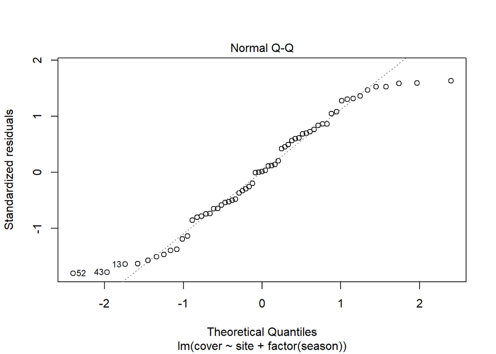

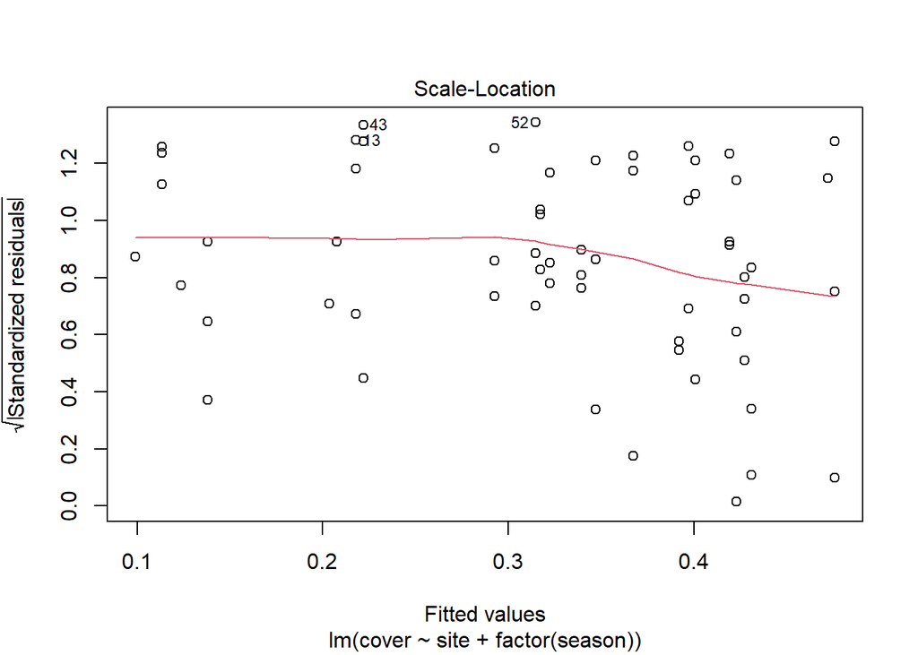

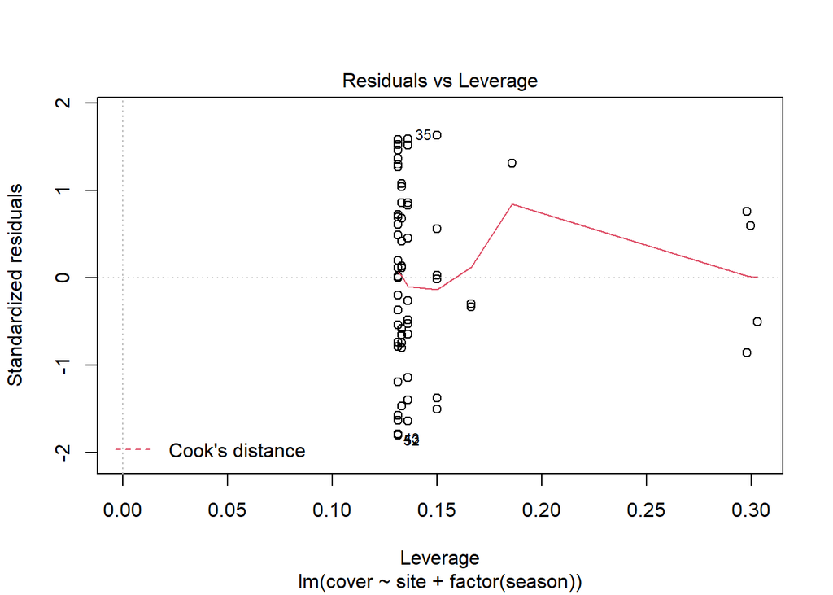

```r
plot (lm2.1)
```

Both significant, plots look good except not sure about the residual vs leverage one

cover ~ site as random factor + season as fixed factor + interaction term

```r
lm2.1 <- lm(cover ~ site + season + site:season, data =all)
lm2.1
```

```
##
## Call:
## lm(formula = cover ~ site + season + site:season, data = all)
##
## Coefficients:
##                  (Intercept)                     sitehs.fp
##                     0.538000                     -0.251667
##                   sitend.eos                     sitepc.cc
##                    -0.172500                      0.044000
##              seasonfall.2019             seasonspring.2019
##                    -0.397000                     -0.083333
##            seasonsummer.2018             seasonsummer.2019
##                    -0.135000                     -0.408667
##            seasonwinter.2018     sitehs.fp:seasonfall.2019
##                    -0.088333                      0.268667
##   sitend.eos:seasonfall.2019     sitepc.cc:seasonfall.2019
##                     0.201500                     -0.020000
##  sitehs.fp:seasonspring.2019  sitend.eos:seasonspring.2019
##                     0.197000                      0.004833
##  sitepc.cc:seasonspring.2019   sitehs.fp:seasonsummer.2018
##                    -0.112333                      0.059333
## sitend.eos:seasonsummer.2018   sitepc.cc:seasonsummer.2018
##                     0.167167                     -0.050667
##  sitehs.fp:seasonsummer.2019  sitend.eos:seasonsummer.2019
##                     0.361667                      0.221833
##  sitepc.cc:seasonsummer.2019   sitehs.fp:seasonwinter.2018
##                    -0.029333                      0.056333
## sitend.eos:seasonwinter.2018   sitepc.cc:seasonwinter.2018
##                     0.003500                      0.017667
```

```r
summary (lm2.1)
```

```
##
## Call:
## lm(formula = cover ~ site + season + site:season, data = all)
##
## Residuals:
##       Min        1Q    Median        3Q       Max
## -0.105000 -0.026667 -0.004333  0.018333  0.137667
##
## Coefficients:
##                               Estimate Std. Error t value Pr(>|t|)
## (Intercept)                   0.538000   0.039178  13.732 4.24e-16 ***
## sitehs.fp                    -0.251667   0.055407  -4.542 5.75e-05 ***
## sitend.eos                   -0.172500   0.061946  -2.785   0.0084 **
## sitepc.cc                     0.044000   0.078357   0.562   0.5778
## seasonfall.2019              -0.397000   0.078357  -5.067 1.15e-05 ***
## seasonspring.2019            -0.083333   0.055407  -1.504   0.1411
## seasonsummer.2018            -0.135000   0.055407  -2.437   0.0198 *
## seasonsummer.2019            -0.408667   0.055407  -7.376 9.00e-09 ***
## seasonwinter.2018            -0.088333   0.055407  -1.594   0.1194
## sitehs.fp:seasonfall.2019     0.268667   0.110813   2.424   0.0203 *
## sitend.eos:seasonfall.2019    0.201500   0.114224   1.764   0.0860 .
## sitepc.cc:seasonfall.2019    -0.020000   0.123893  -0.161   0.8726
## sitehs.fp:seasonspring.2019   0.197000   0.078357   2.514   0.0164 *
## sitend.eos:seasonspring.2019  0.004833   0.083110   0.058   0.9539
## sitepc.cc:seasonspring.2019  -0.112333   0.095967  -1.171   0.2493
## sitehs.fp:seasonsummer.2018   0.059333   0.078357   0.757   0.4537
## sitend.eos:seasonsummer.2018  0.167167   0.083110   2.011   0.0516 .
## sitepc.cc:seasonsummer.2018  -0.050667   0.095967  -0.528   0.6007
## sitehs.fp:seasonsummer.2019   0.361667   0.078357   4.616 4.59e-05 ***
## sitend.eos:seasonsummer.2019  0.221833   0.083110   2.669   0.0112 *
## sitepc.cc:seasonsummer.2019  -0.029333   0.095967  -0.306   0.7616
## sitehs.fp:seasonwinter.2018   0.056333   0.078357   0.719   0.4767
## sitend.eos:seasonwinter.2018  0.003500   0.083110   0.042   0.9666
## sitepc.cc:seasonwinter.2018   0.017667   0.095967   0.184   0.8549
## ---
## Signif. codes:  0 '***' 0.001 '**' 0.01 '*' 0.05 '.' 0.1 ' ' 1
##
## Residual standard error: 0.06786 on 37 degrees of freedom
## Multiple R-squared:  0.8498, Adjusted R-squared:  0.7564
## F-statistic:   9.1 on 23 and 37 DF,  p-value: 3.148e-09
```

```r
anova (lm2.1)
```

```
## Analysis of Variance Table
##
## Response: cover
##             Df  Sum Sq  Mean Sq F value    Pr(>F)
## site         3 0.13228 0.044095  9.5758 8.168e-05 ***
## season       5 0.55669 0.111338 24.1784 9.952e-11 ***
## site:season 15 0.27486 0.018324  3.9793 0.0003102 ***
## Residuals   37 0.17038 0.004605
## ---
## Signif. codes:  0 '***' 0.001 '**' 0.01 '*' 0.05 '.' 0.1 ' ' 1
```

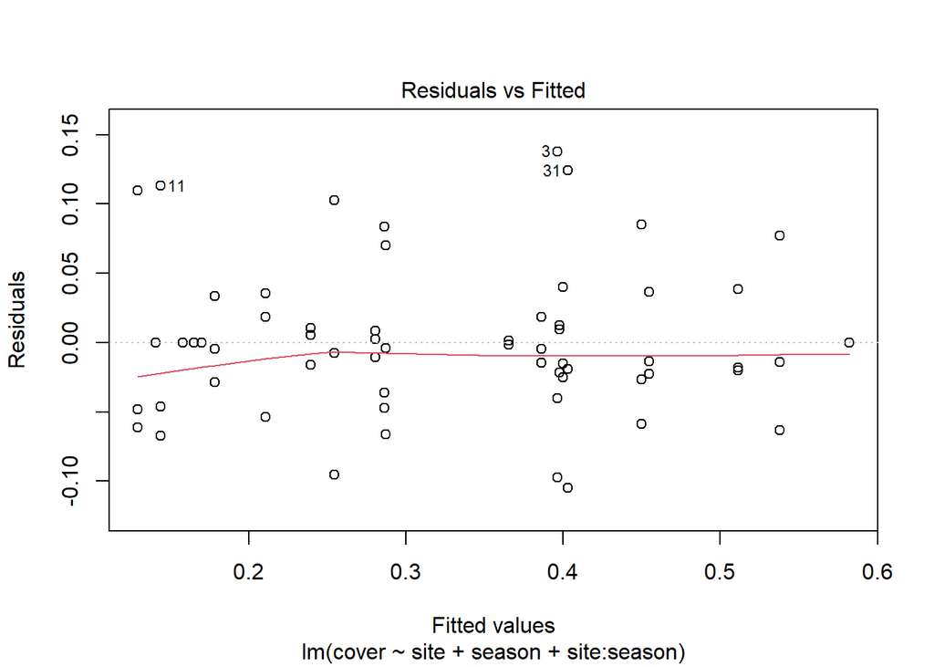

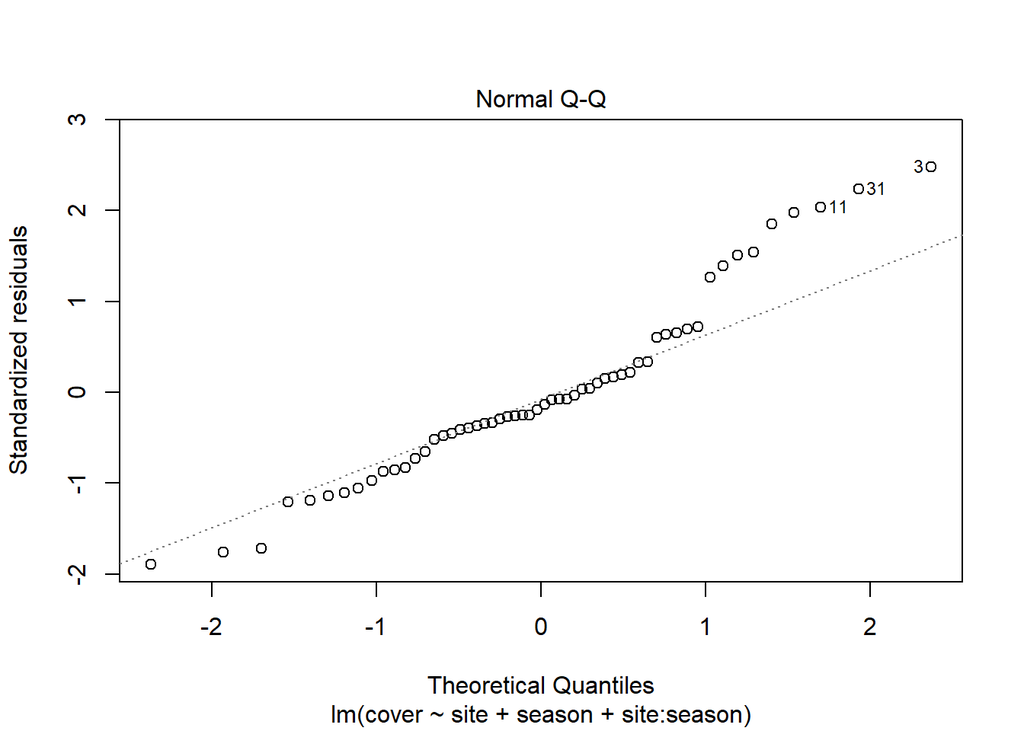

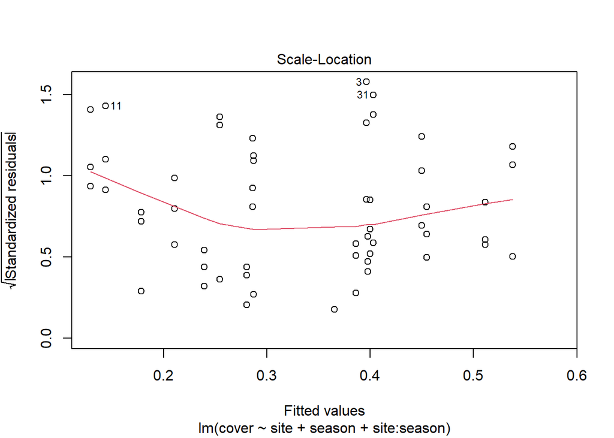

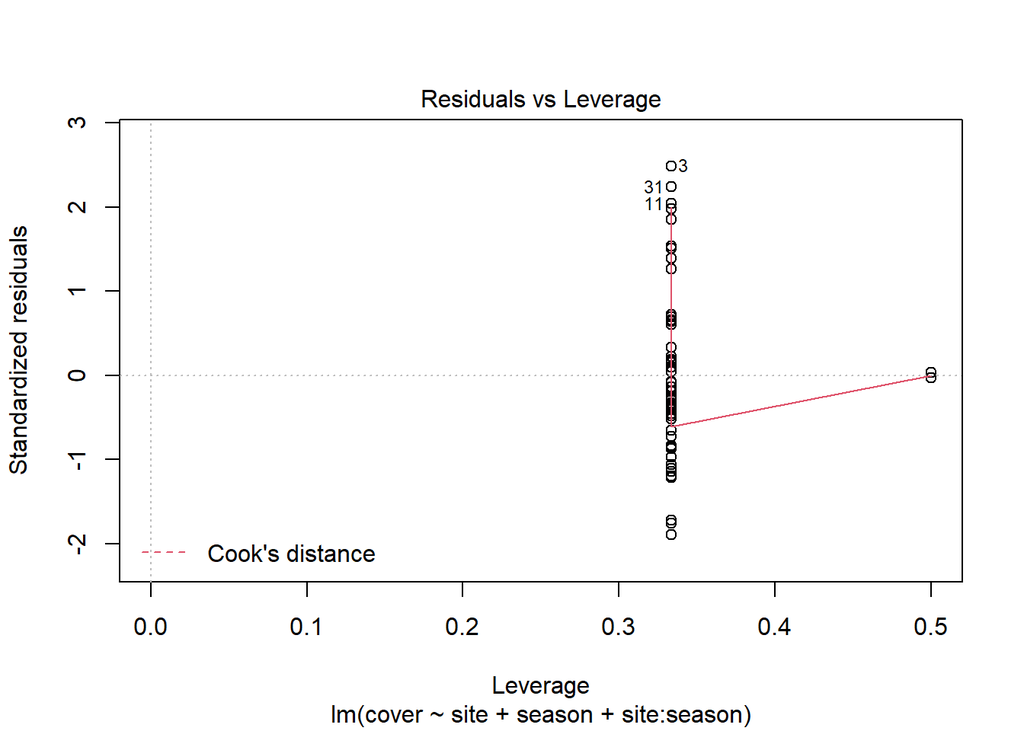

```r
plot (lm2.1)
```

All significant, more significance than previous model, plots look good except again I’m not sure about the residual vs leverage one

####2.2 Is there a difference in Fucus total density between site and time?####  
density ~ site as random factor + season as fixed factor

```r
lm2.2 <- lm(no.fuc.q ~ site + factor(season), data =all)
lm2.2
```

```
##
## Call:
## lm(formula = no.fuc.q ~ site + factor(season), data = all)
##
## Coefficients:
##               (Intercept)                  sitehs.fp
##                    64.533                    -30.363
##                sitend.eos                  sitepc.cc
##                    -8.564                     -2.281
##   factor(season)fall.2019  factor(season)spring.2019
##                   -30.356                    -31.214
## factor(season)summer.2018  factor(season)summer.2019
##                    20.411                    -31.906
## factor(season)winter.2018
##                   -32.448
```

```r
summary (lm2.2)
```

```
##
## Call:
## lm(formula = no.fuc.q ~ site + factor(season), data = all)
##
## Residuals:
##     Min      1Q  Median      3Q     Max
## -52.663 -15.219  -4.604  13.946  80.837
##
## Coefficients:
##                           Estimate Std. Error t value Pr(>|t|)
## (Intercept)                 64.533     10.053   6.419 4.16e-08 ***
## sitehs.fp                  -30.363      9.174  -3.310  0.00170 **
## sitend.eos                  -8.564      9.340  -0.917  0.36338
## sitepc.cc                   -2.281      9.559  -0.239  0.81234
## factor(season)fall.2019    -30.356     15.643  -1.941  0.05775 .
## factor(season)spring.2019  -31.214     11.511  -2.712  0.00905 **
## factor(season)summer.2018   20.411     11.511   1.773  0.08205 .
## factor(season)summer.2019  -31.906     11.511  -2.772  0.00772 **
## factor(season)winter.2018  -32.448     11.511  -2.819  0.00680 **
## ---
## Signif. codes:  0 '***' 0.001 '**' 0.01 '*' 0.05 '.' 0.1 ' ' 1
##
## Residual standard error: 25.95 on 52 degrees of freedom
## Multiple R-squared:  0.5107, Adjusted R-squared:  0.4354
## F-statistic: 6.784 on 8 and 52 DF,  p-value: 4.606e-06
```

```r
anova (lm2.2)
```

```
## Analysis of Variance Table
##
## Response: no.fuc.q
##                Df Sum Sq Mean Sq F value    Pr(>F)
## site            3   8534  2844.5  4.2247  0.009534 **
## factor(season)  5  28008  5601.6  8.3195 7.835e-06 ***
## Residuals      52  35012   673.3
## ---
## Signif. codes:  0 '***' 0.001 '**' 0.01 '*' 0.05 '.' 0.1 ' ' 1
```

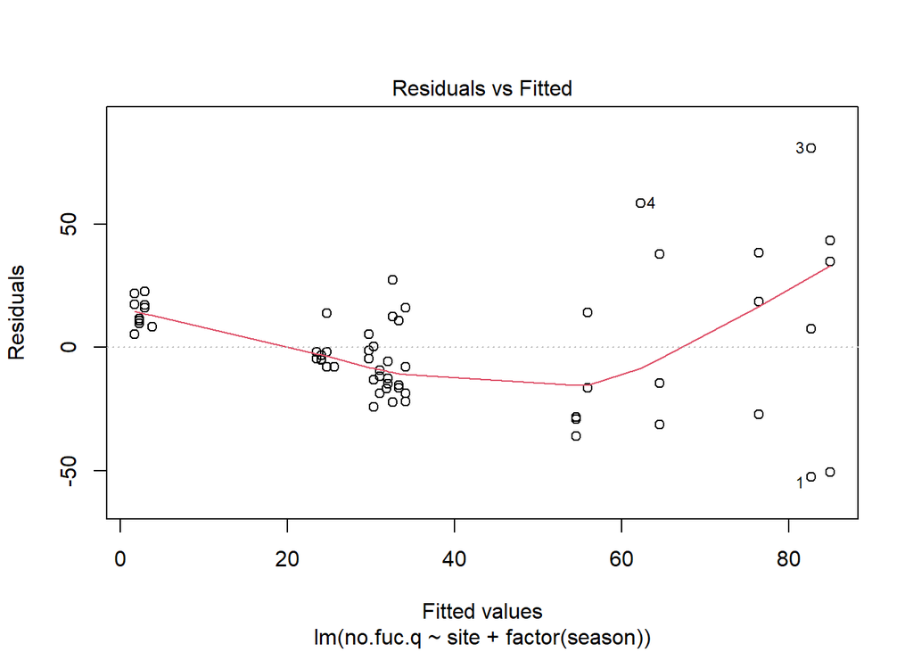

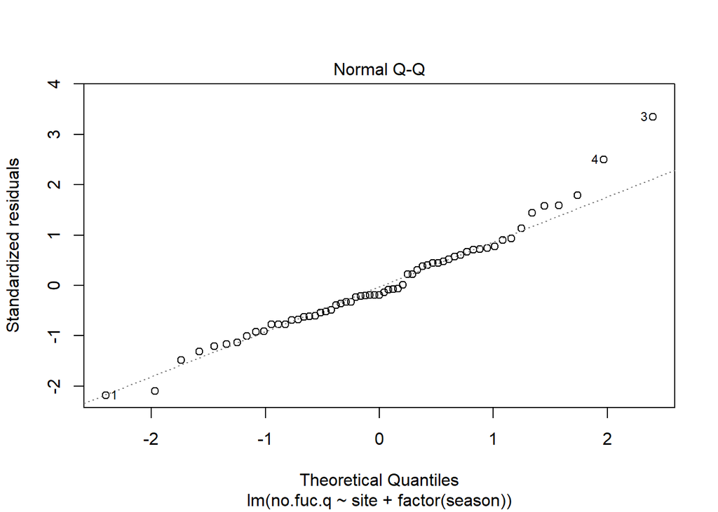

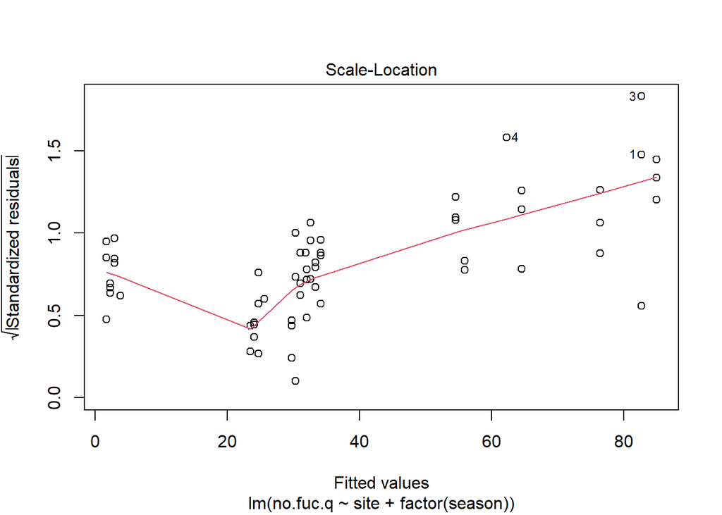

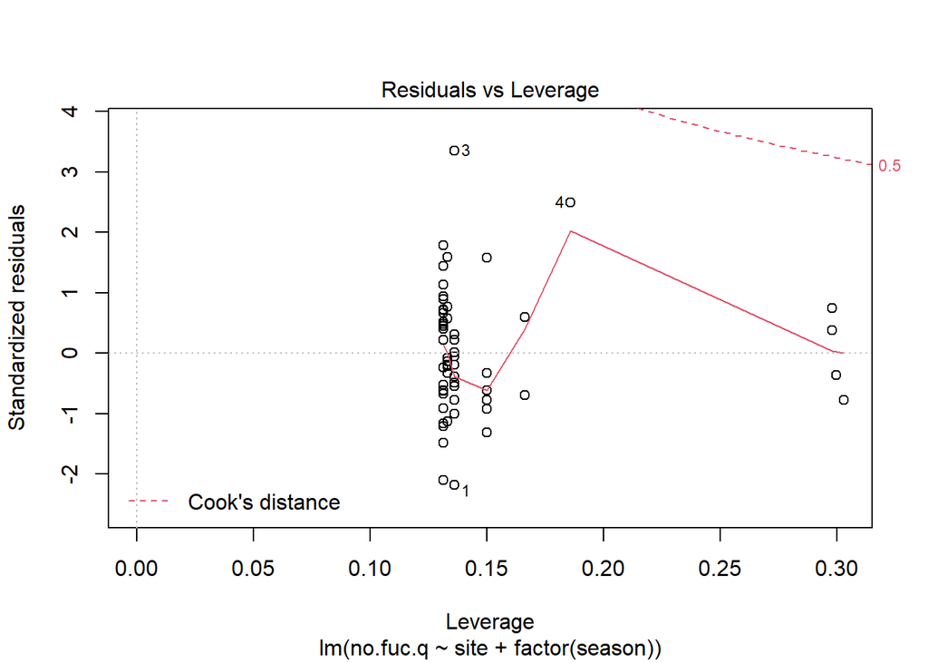

```r
plot (lm2.2)
```

site as random factor + season as fixed factor + interaction term

```r
lm2.2 <- lm(no.fuc.q ~ site + factor(season) + site:season, data =all)
lm2.2
```

```
##
## Call:
## lm(formula = no.fuc.q ~ site + factor(season) + site:season,
##     data = all)
##
## Coefficients:
##                  (Intercept)                     sitehs.fp
##                       61.833                       -43.767
##                   sitend.eos                     sitepc.cc
##                       -6.933                        58.967
##      factor(season)fall.2019     factor(season)spring.2019
##                     -105.700                      -103.000
##    factor(season)summer.2018     factor(season)summer.2019
##                      -26.233                      -102.800
##    factor(season)winter.2018     siteby.rb:seasonfall.2019
##                      -91.233                        94.267
##    sitehs.fp:seasonfall.2019    sitend.eos:seasonfall.2019
##                       99.833                        68.600
##    sitepc.cc:seasonfall.2019   siteby.rb:seasonspring.2019
##                           NA                        67.600
##  sitehs.fp:seasonspring.2019  sitend.eos:seasonspring.2019
##                      106.567                        74.300
##  sitepc.cc:seasonspring.2019   siteby.rb:seasonsummer.2018
##                           NA                        58.533
##  sitehs.fp:seasonsummer.2018  sitend.eos:seasonsummer.2018
##                       31.700                        57.667
##  sitepc.cc:seasonsummer.2018   siteby.rb:seasonsummer.2019
##                           NA                        79.533
##  sitehs.fp:seasonsummer.2019  sitend.eos:seasonsummer.2019
##                       97.767                        67.600
##  sitepc.cc:seasonsummer.2019   siteby.rb:seasonwinter.2018
##                           NA                        50.533
##  sitehs.fp:seasonwinter.2018  sitend.eos:seasonwinter.2018
##                       89.800                        56.133
##  sitepc.cc:seasonwinter.2018
##                           NA
```

```r
summary (lm2.2)
```

```
##
## Call:
## lm(formula = no.fuc.q ~ site + factor(season) + site:season,
##     data = all)
##
## Residuals:
##     Min      1Q  Median      3Q     Max
## -64.567  -4.367   0.000   5.267  68.933
##
## Coefficients: (5 not defined because of singularities)
##                              Estimate Std. Error t value Pr(>|t|)
## (Intercept)                    61.833     14.231   4.345 0.000104 ***
## sitehs.fp                     -43.767     20.126  -2.175 0.036125 *
## sitend.eos                     -6.933     22.502  -0.308 0.759714
## sitepc.cc                      58.967     28.462   2.072 0.045316 *
## factor(season)fall.2019      -105.700     34.859  -3.032 0.004418 **
## factor(season)spring.2019    -103.000     28.462  -3.619 0.000880 ***
## factor(season)summer.2018     -26.233     28.462  -0.922 0.362666
## factor(season)summer.2019    -102.800     28.462  -3.612 0.000897 ***
## factor(season)winter.2018     -91.233     28.462  -3.205 0.002778 **
## siteby.rb:seasonfall.2019      94.267     45.003   2.095 0.043106 *
## sitehs.fp:seasonfall.2019      99.833     45.003   2.218 0.032748 *
## sitend.eos:seasonfall.2019     68.600     46.114   1.488 0.145329
## sitepc.cc:seasonfall.2019          NA         NA      NA       NA
## siteby.rb:seasonspring.2019    67.600     34.859   1.939 0.060128 .
## sitehs.fp:seasonspring.2019   106.567     34.859   3.057 0.004136 **
## sitend.eos:seasonspring.2019   74.300     36.283   2.048 0.047726 *
## sitepc.cc:seasonspring.2019        NA         NA      NA       NA
## siteby.rb:seasonsummer.2018    58.533     34.859   1.679 0.101553
## sitehs.fp:seasonsummer.2018    31.700     34.859   0.909 0.369040
## sitend.eos:seasonsummer.2018   57.667     36.283   1.589 0.120486
## sitepc.cc:seasonsummer.2018        NA         NA      NA       NA
## siteby.rb:seasonsummer.2019    79.533     34.859   2.282 0.028365 *
## sitehs.fp:seasonsummer.2019    97.767     34.859   2.805 0.007980 **
## sitend.eos:seasonsummer.2019   67.600     36.283   1.863 0.070394 .
## sitepc.cc:seasonsummer.2019        NA         NA      NA       NA
## siteby.rb:seasonwinter.2018    50.533     34.859   1.450 0.155583
## sitehs.fp:seasonwinter.2018    89.800     34.859   2.576 0.014120 *
## sitend.eos:seasonwinter.2018   56.133     36.283   1.547 0.130348
## sitepc.cc:seasonwinter.2018        NA         NA      NA       NA
## ---
## Signif. codes:  0 '***' 0.001 '**' 0.01 '*' 0.05 '.' 0.1 ' ' 1
##
## Residual standard error: 24.65 on 37 degrees of freedom
## Multiple R-squared:  0.6858, Adjusted R-squared:  0.4905
## F-statistic: 3.512 on 23 and 37 DF,  p-value: 0.0003338
```

```r
anova (lm2.2)
```

```
## Analysis of Variance Table
##
## Response: no.fuc.q
##                Df  Sum Sq Mean Sq F value    Pr(>F)
## site            3  8533.5  2844.5  4.6817  0.007177 **
## factor(season)  5 28008.2  5601.6  9.2195 9.154e-06 ***
## site:season    15 12531.6   835.4  1.3750  0.210492
## Residuals      37 22480.6   607.6
## ---
## Signif. codes:  0 '***' 0.001 '**' 0.01 '*' 0.05 '.' 0.1 ' ' 1
```

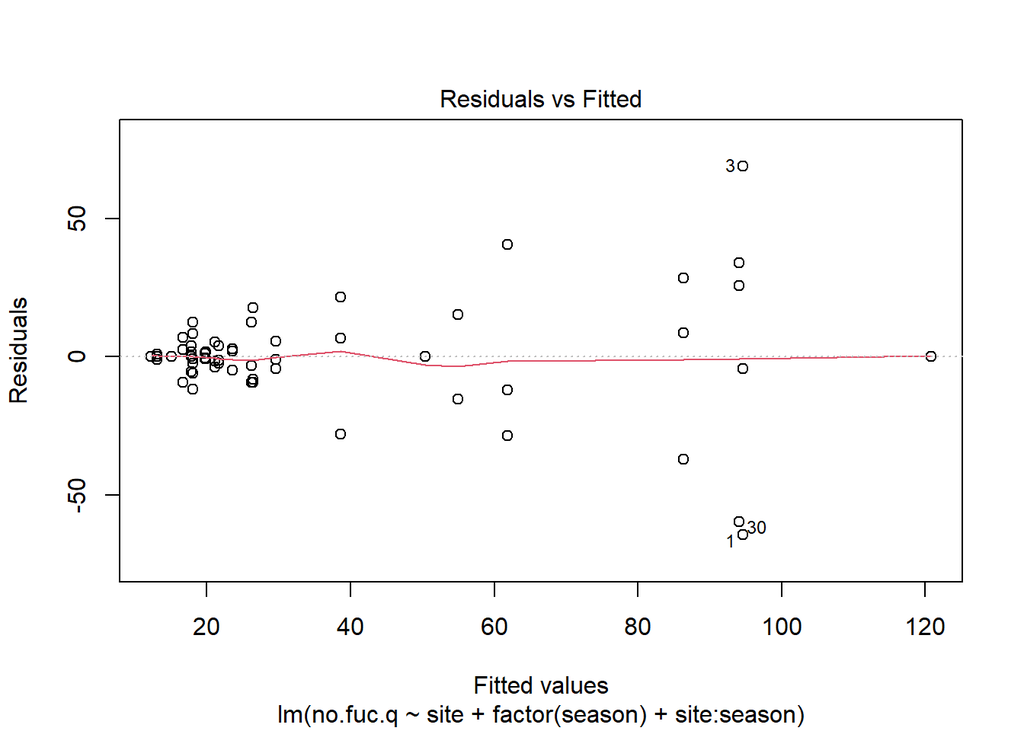

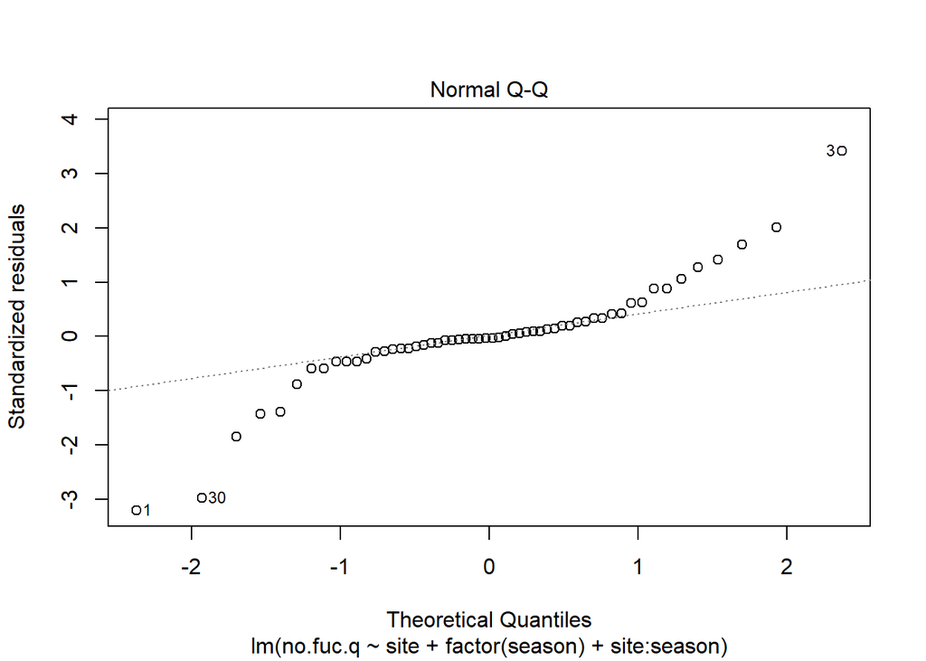

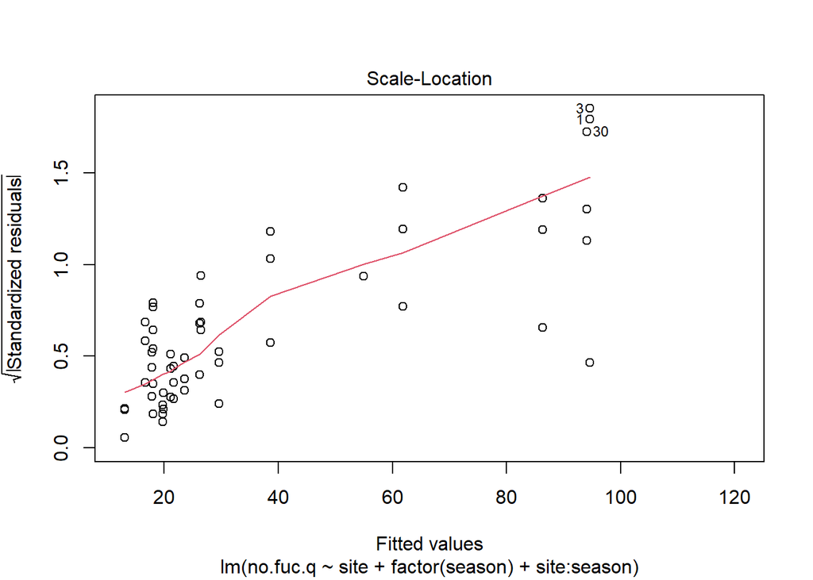

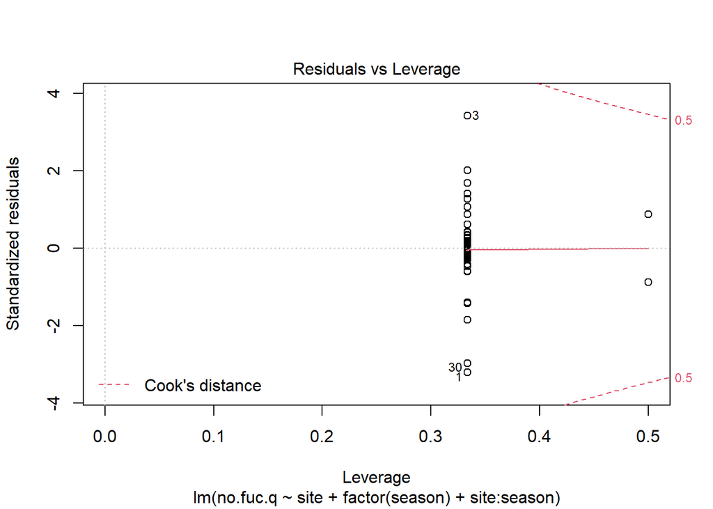

```r
plot (lm2.2)
```

####REPRODUCTIVE PHENOLOGY (with seasonality)####  
3. Is reproduction affected by the season?